# Discrete Distributions

## Mathematical Symbols - Summation

\(\sum_{i=1}^N\) - sum from index \(i = 1\) to \(N\).

For example, consider \(x = (1,2,3,4,5)\),

\[ \sum_{i=1}^5 x_i = 15 \]

In R this is equivalent to

```r
x <- c(1,2,3,4,5)
sum(x)
```

```
## [1] 15
```

## Mathematical Symbols - Product

\(\prod_{i=1}^N\) - product from index \(i = 1\) to \(N\).

For example, consider \(x = (1,2,3,4,5)\),

\[ \prod_{i=1}^5 x_i = 120. \]

```r
x <- c(1,2,3,4,5)
prod(x)
```

```
## [1] 120
```

## For Loop - Sum and Product

```r
val.sum <- 0
for(i in 1:length(x)) val.sum <- val.sum + x[i]
val.sum
```

```
## [1] 15
```

```r
val.prod <- 1
for(i in 1:length(x)) val.prod <- val.prod * x[i]
val.prod
```

```
## [1] 120
```

## Discrete Random Variable

1. Quantity that is a result of a random event denoted as \(X\).
2. Takes on non-negative integer values.
3. Presence/Absence of fish, Count of fish, …
4. The distribution describing this is called a probability mass function (pmf), which we will generally reference as \(f(X)\).
5. When we observe it we will call it \(x_i\) for the \(i\)th observation.

## Discrete Probability

1. The chance of a random event occurring.
2. E.g. The chance of observing a male/female fish.
3. We may define this as \(X = 0\) if male and \(X = 1\) if female.
4. What is the probability of a female fish? Or, \(f(X = 1)\)?
5. What is the probability of the two observed fish being female? \(f(x_1 = 1, x_2 = 1)\)?

## Importance of Indepenence

1. If \(x_1\) and \(x_2\) are independent, then by definition

\[ f(x_1 = 1, x_2 = 1) = f(x_1) \times f(x_2) \]

1. Otherwise we say the two events are dependent.
2. (Class discussion)

## Expectation

1. The theoretical or population mean.

\[ \mathbf{E}(X) = \sum_{X = 0}^\infty X f(X) \]

```r
## p(male fish) = 0.2, p(female fish) = 0.8
0*0.2 + 0.8*1
```

```
## [1] 0.8
```

## Sample Mean

1. Assuming a simple random sample of size \(n\),

\[ \bar{x} = \frac{ \sum_{i=1}^n x_i}{n} \]

```r
## p(male fish) = 0.3, p(female fish) = 0.7
x <- sample(c("male", "female"), 10, prob = c(0.3,0.7), replace = TRUE)
sum(x == "female")/10
```

```
## [1] 0.7
```

```r
mean(x == "female")
```

```
## [1] 0.7
```

## Variance

\[ \begin{align} Var(X) &=& \mathbf{E}[\{X - \mathbf{E}(X)\}^2] \\ &=& \mathbf{E}\{X^2 -2 X \mathbf{E}(X) + \mathbf{E}(X)^2 \} \\ &=& \mathbf{E}(X^2) -2 \mathbf{E}\{X \mathbf{E}(X)\} + \mathbf{E}(X)^2 \\ &=& \mathbf{E}(X^2) - \mathbf{E}(X)^2 \end{align} \]

## Sample Variance

1. Assuming a simple random sample of size \(n\),

\[ Var(x_i) = \frac{ \sum_{i=1}^n (x_i - \bar{x})^2 }{n-1} \]

```r
## p(male fish) = 0.3, p(female fish) = 0.7
x <- sample(c("male", "female"), 10, prob = c(0.3,0.7), replace = TRUE)
avg <- sum(x == "female")/10
sum(((x == "female") - avg)^2)/9
```

```
## [1] 0.1
```

```r
var((x == "female")*1)
```

```
## [1] 0.1
```

## Sample Variance Bias

```r
  ## Check Variance without that n-1 correction.
  VarWrong <- function(x){sum((x-mean(x))^2)/length(x)}
  var.w <- NULL; var.c <- NULL;
  for(i in 1:1000){
    smp.data <- rnorm(10, 0, 1.2)
    var.w <- c(var.w, VarWrong(smp.data))
  }
```

```r
  ## Bias of variance
  mean(var.w - 1.2^2)
```

```
## [1] -0.121658
```

```r
  ## Bias correction factor n/n-1...
  var.c <- var.w*10/9
  mean(var.c - 1.2^2)
```

```
## [1] 0.02482446
```

## Covariance

1. Covariance between two random variables is defined as

\[ \text{Cov}(X, Y) = \mathbf{E}(XY) - \mathbf{E}(X)\mathbf{E}(Y). \] 1. Not correlated doesn’t imply independence.

```r
x <- rnorm(1000, 0, 0.5)
x2 <- x^2 + rnorm(1000, 0, 0.25)
cov(x, x2)
```

```
## [1] 0.01429434
```

## Covariance

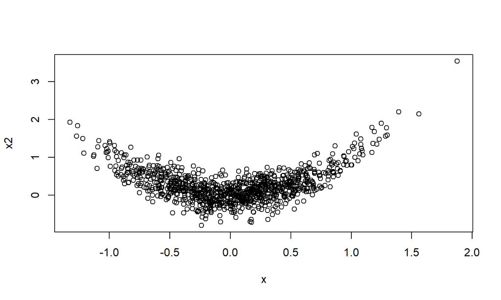

```r
plot(x, x2)
```

## Important Rule of Variance!

1. Assuming \(x_1\) and \(x_2\) are independent.
2. \(Var(x_1 + x_2) = Var(x_1) + Var(x_2)\)
3. If \(x_i \sim iid\), \[ Var(\sum_{i=1}^n x_i) = n \times Var(x_i) \] \[ Var(\bar{x}) = \frac{n \times Var(x_i)}{n^2} = \frac{Var(x_i)}{n} \]

## Standard Deviation + Error

1. Standard Deviation \[ SD(X) = \sqrt{Var(X)} \]
2. Standard Erorr = Standard Deviation of the Mean

\[ SD(\bar{x}) = \sqrt{Var(\bar{x})} = \frac{SD(x_i)}{\sqrt{n}} \]

## Statistic

1. A quantity calculated from sample data.
2. Sea cucumbers
- Count on a single quadrat. Yes
- Counts on mulitple quadrats. No
- Average from mulitple quadrats. Yes
1. Sample Mean
2. Sample Variance
3. Quantiles
4. Max, Min

## Bernoulli Distribution

1. Presence/Absence with probability \(p\). \(X \in 0,1\).
2. Mean \(\mathbb{E}(X) = p\).
3. Variance \(Var(X) = p(1-p)\).
4. Examples?

## Bernoulli Distribution

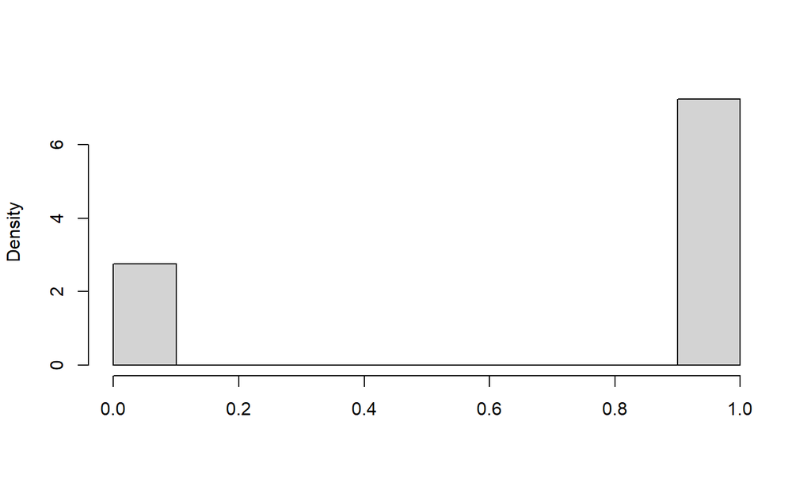

```r
  rb <- rbinom(1000, size = 1, prob = 0.7)
  hist(rb, xlab = "", main = "", freq = FALSE)
```

## Binomial Distribution

1. \(n\) repeated Binomial trials, with probability of success \(p\).
2. Count number of successes.
3. Example, number of female fish caught given you caught \(n = 10\).
4. Mean \(\mathbb{E}(X) = np\).
5. Variance \(Var(X) = np(1-p)\).

## Binomial Distribution

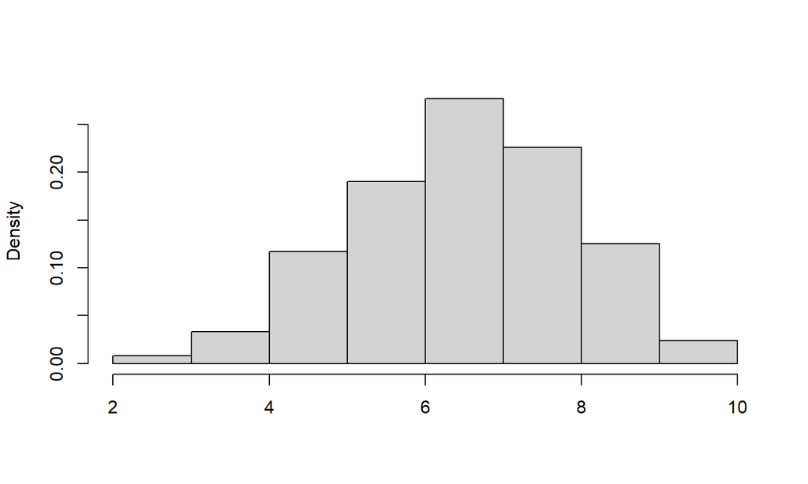

```r
  rbn <- rbinom(1000, size = 10, prob = 0.7)
  hist(rbn, xlab = "", main = "", freq = FALSE)
```

## Geometric Distribution

1. Run a Bernoulli experiment with probability \(p\), but stop when you’ve reached the first success and record number of failures.
2. Example, need to collect a nudibranch from a tidepool. Count the number of tidepools until you encounter one.
3. Mean \(\mathbb{E}(X) = \frac{1-p}{p}\).
4. Variance \(Var(X) = \frac{1-p}{p^2}\).

## Geometric Distribution

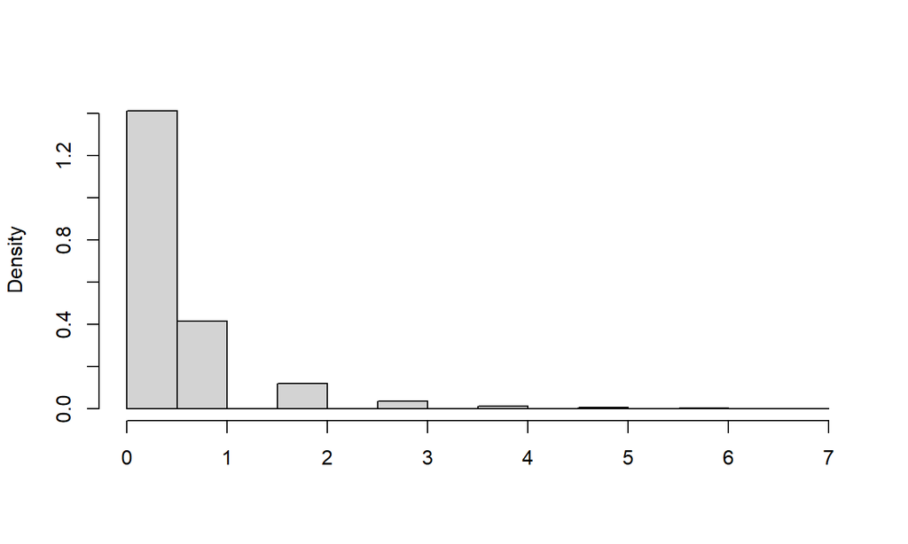

```r
  rg <- rgeom(10000, prob = 0.7) # This returns the number of failures.
  hist(rg, xlab = "", main = "", freq = FALSE)
```

## Poisson Distribution

1. Count with rate \(\lambda\), \(X \in 0,1,2,\ldots\).
2. Can think of it as a Binomial where \(p = \frac{\lambda}{n}\) and \(n \to \infty\).
3. Example, any count
4. Mean \(\mathbb{E}(X) = \lambda\).
5. Variance \(Var(X) =\lambda\).

## Poisson Distribution

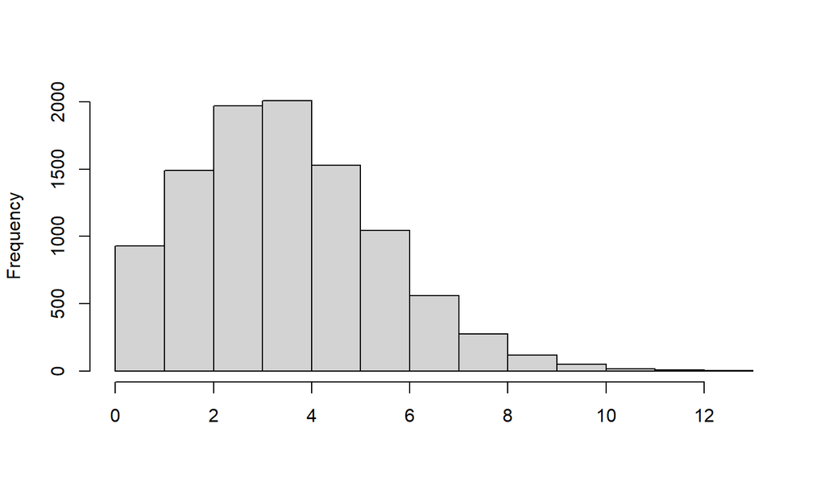

```r
  rp <- rpois(10000, lambda = 4)
  hist(rp, main = "", xlab = "", freq = TRUE)
```

## Poisson Distribution

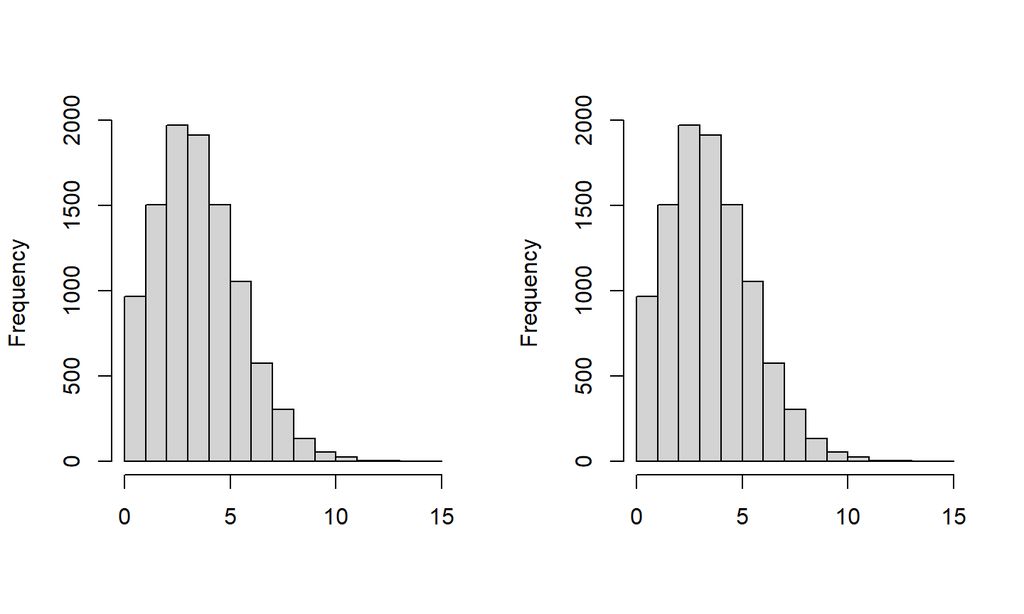

```r
  rp <- rpois(10000, lambda = 4)
  rb <- rbinom(10000, prob = 4/1000000, size = 1000000)
  par(mfrow = c(1,2))
  hist(rp, main = "", xlab = "", freq = TRUE)
  hist(rp, main = "", xlab = "", freq = TRUE)
```

## Negative Binomial Distribution

1. Poisson count with over/under dispersion.
2. Shape \(r\) and Scale \(\theta\), \(X \in 0,1,2,\ldots\).
3. Lots of parameterizations. Always check what you’re using. 1 Default in R is size \(n\) and probability \(p\) of a trial. It also can use the mean \(\mu = n(1-p)/p\) as we show below.
4. Mean \(\mathbb{E}(X) = \frac{n(1-p)}{p}\).
5. Variance \(Var(X) = \frac{n(1-p)}{p^2}\).
6. What count data might need to be modelled with the Negative Binomial?

## Negative Binomial Distribution

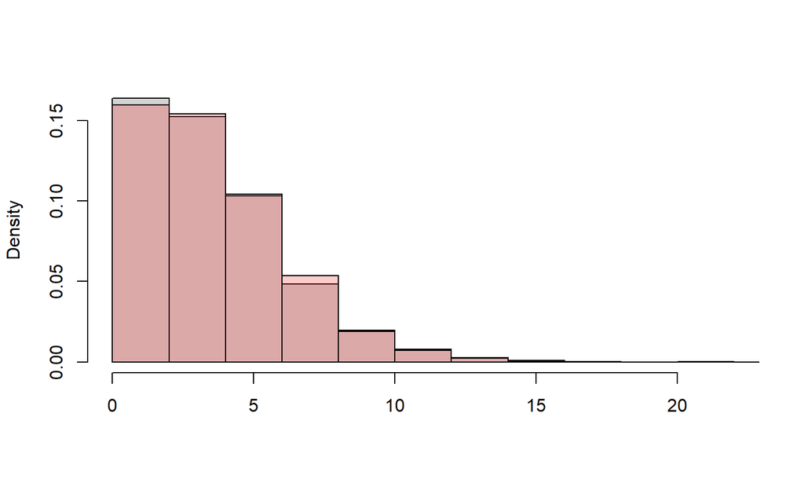

```r
  rnb.mu <- rnbinom(10000, mu = 4, size = 5)
  p <- 1/(1+4/5)
  rnb.p <- rnbinom(10000, p = p, size = 5)

  hist(rnb.mu, main = "", xlab = "", freq = FALSE)
  hist(rnb.p, add=TRUE, col = rgb(1, 0, 0, alpha = 0.2), freq = FALSE)
```

## Poisson Gamma Mixture

Alternatively you can define it as,

\[ \begin{align} X & \sim \text{Poisson}(\lambda)\\ \lambda & \sim \text{Gamma}(r, \theta) \end{align} \]

```r
  p <- 1/(1+4/5)
  rnb.p <- rnbinom(10000, p = p, size = 5)
  scale <- (1-p)/p
  shape = 5

  lam <- rgamma(10000, scale = scale, shape = shape)
  pois.gam <- rpois(10000, lambda = lam)
```

## Poisson Gamma Mixture

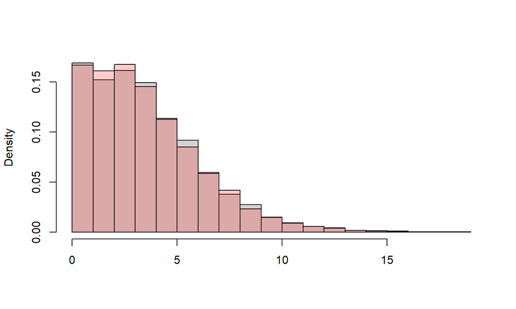

```r
  hist(rnb.p, main = "", xlab = "", freq = FALSE)
  hist(pois.gam, add=TRUE, col = rgb(1, 0, 0, alpha = 0.2), freq = FALSE)
```